# InVivoStat Single Measure Parametric Analysis

## Response and covariate

The Resp 1 response is currently being analysed by the Single Measures Parametric Analysis module, with Cov 1 fitted as a covariate.The covariate has been square root transformed prior to analysis.

## Scatterplot of the observed data

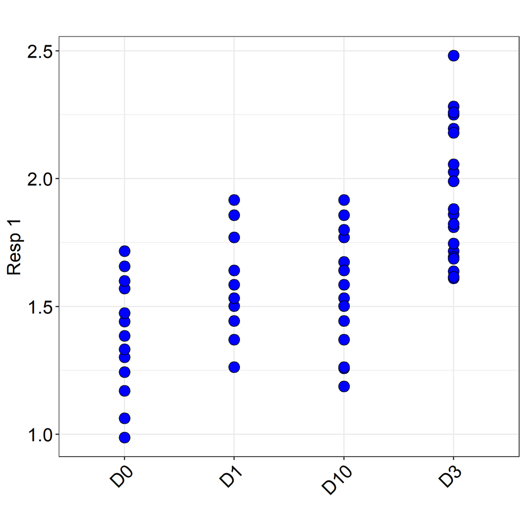

Tip: Use this plot to identify possible outliers.

## Plot of the response vs. the covariate, categorised by the primary factor (on the transformed scale)

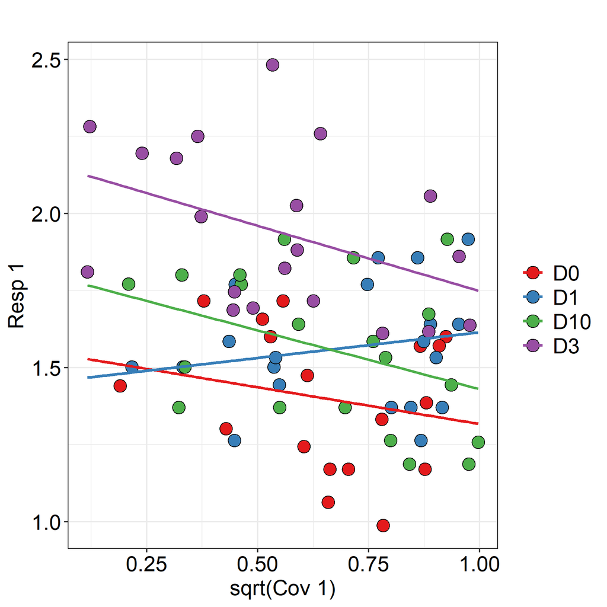

Tip: In order to decide whether it is helpful to fit the covariate, the following should be considered:

a) Is there a relationship between the response and the covariate? (N.B., It is only worth fitting the covariate if there is a strong positive (or negative) relationship between them: i.e., the lines on the plot should not be horizontal).

b) Is the relationship similar for all treatments? (The lines on the plot should be approximately parallel).

c) Is the covariate influenced by the treatment? (We assume the covariate is not influenced by the treatment and so there should be no separation of the treatment groups along the x-axis on the plot).

These issues are discussed in more detail in Morris (1999).

## Analysis of Covariance (ANCOVA) table for assessing covariate interactions

| Effect | Sums of squares | Degrees of freedom | Mean square | F-value | p-value |
| --- | --- | --- | --- | --- | --- |
| Cov 1 | 0.190 | 1 | 0.190 | 3.68 | 0.0592 |
| Treat1 | 0.800 | 3 | 0.267 | 5.17 | 0.0028 |
| Cov 1 * Treat1 | 0.234 | 3 | 0.078 | 1.52 | 0.2181 |
| Residual | 3.609 | 70 | 0.052 |  |  |

Note: This table should only be used to assess the covariate interactions. The statistical model used to generate all the remaining results in this output does not include the covariate interactions.

Comment: ANCOVA table calculated using a Type III model fit, see Armitage et al. (2001).

## Analysis of Covariance (ANCOVA) table

| Effect | Sums of squares | Degrees of freedom | Mean square | F-value | p-value |
| --- | --- | --- | --- | --- | --- |
| Cov 1 | 0.225 | 1 | 0.225 | 4.28 | 0.0421 |
| Treat1 | 2.619 | 3 | 0.873 | 16.58 | < 0.0001 |
| Residual | 3.843 | 73 | 0.053 |  |  |

Comment: ANCOVA table calculated using a Type III model fit, see Armitage et al. (2001).

Conclusion: At the 5% level, there is a statistically significant overall difference between the levels of Cov 1, Treat1.

Tip: While it is a good idea to consider the overall tests in the ANCOVA table, we should not rely on them when deciding whether or not to make pairwise comparisons.

## Model coefficients

|  | Estimate | Std. Error | t-value | p-value |
| --- | --- | --- | --- | --- |
| (Intercept) | 1.7654 | 0.0768 | 22.99 | < 0.0001 |
| Cov 1 | -0.2338 | 0.1130 | -2.07 | 0.0421 |
| Treat11 | -0.2129 | 0.0463 | -4.60 | < 0.0001 |
| Treat12 | -0.0390 | 0.0451 | -0.87 | 0.3894 |
| Treat13 | -0.0508 | 0.0447 | -1.14 | 0.2590 |

## Covariate regression coefficient

| Covariate | Estimate | Std error | t-value | p-value |
| --- | --- | --- | --- | --- |
| Cov 1 | -0.234 | 0.113 | -2.07 | 0.0421 |

## Diagnostic plots

### Residuals vs. predicted plot

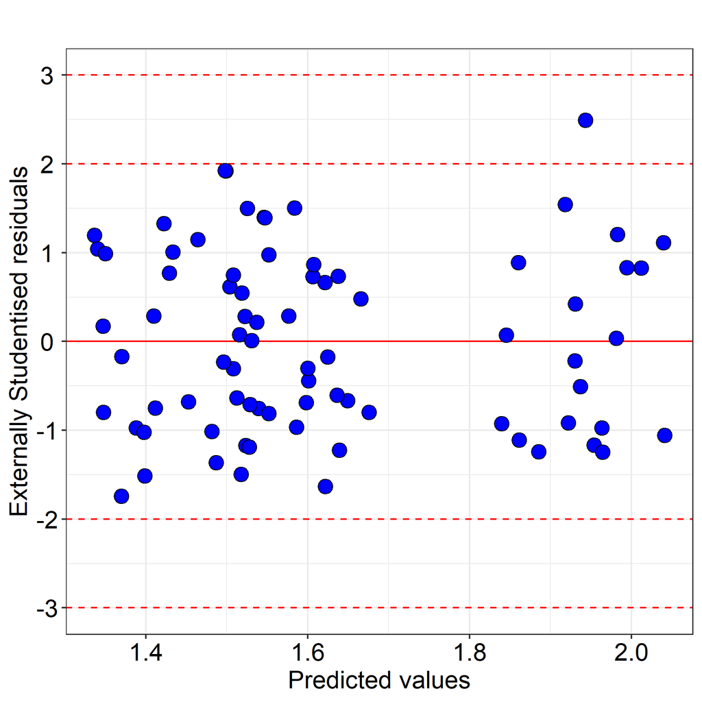

Tip: On this plot look to see if the spread of the points increases as the predicted values increase. If so the response may need transforming.

Tip: Any observation with a residual less than -3 or greater than 3 (SD) should be investigated as a possible outlier.

### Normal probability plot

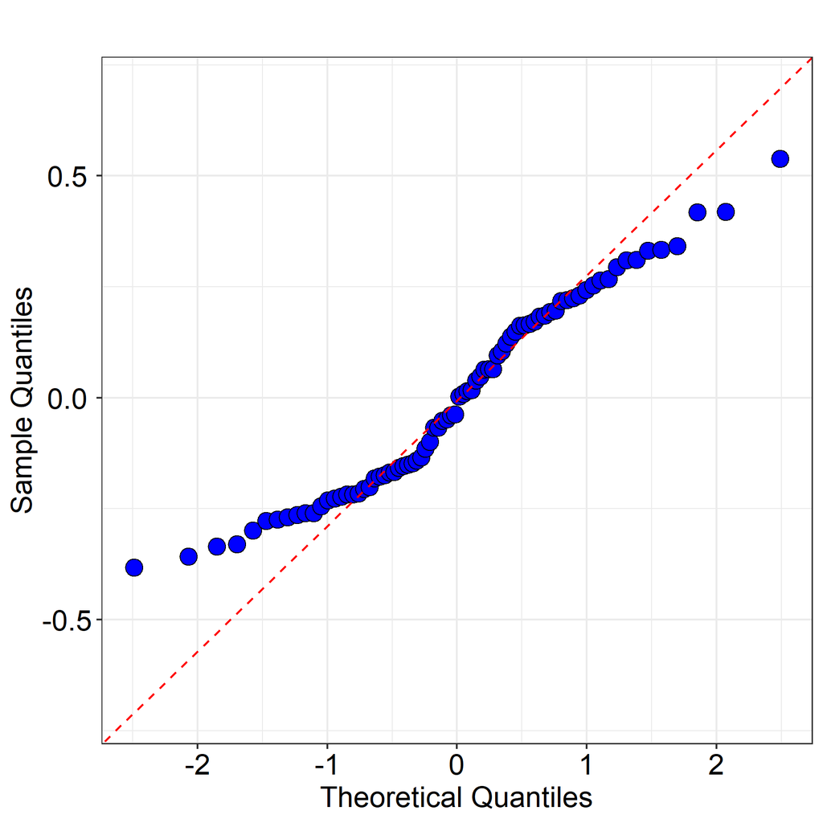

Tip: Check that the points lie along the dotted line. If not then the data may be non-normally distributed.

## Table of the least square (predicted) means with 95% confidence intervals

| Mean ID | Treat1 | Mean | Lower 95% CI | Upper 95% CI |
| --- | --- | --- | --- | --- |
| 1 | D0 | 1.403 | 1.295 | 1.511 |
| 2 | D1 | 1.577 | 1.474 | 1.680 |
| 3 | D10 | 1.565 | 1.463 | 1.668 |
| 4 | D3 | 1.919 | 1.815 | 2.023 |

## Plot of the least square (predicted) means with 95% confidence intervals

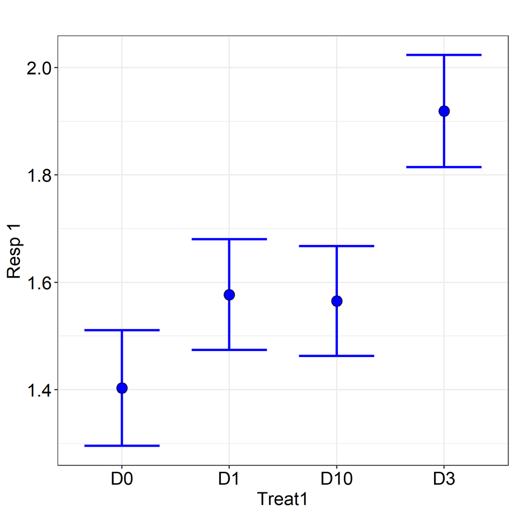

## All pairwise comparisons using Holm's procedure

| Comparison | Difference | Lower 95% CI | Upper 95% CI | Std error | p-value |
| --- | --- | --- | --- | --- | --- |
| D0 - D1 | -0.174 | -0.323 | -0.025 | 0.075 | 0.0679 |
| D0 - D10 | -0.162 | -0.311 | -0.014 | 0.075 | 0.0679 |
| D0 - D3 | -0.516 | -0.666 | -0.365 | 0.076 | < 0.0001 |
| D1 - D10 | 0.012 | -0.133 | 0.157 | 0.073 | 0.8715 |
| D1 - D3 | -0.342 | -0.490 | -0.193 | 0.074 | < 0.0001 |
| D10 - D3 | -0.354 | -0.500 | -0.207 | 0.074 | < 0.0001 |

Conclusion: The following pairwise comparisons are statistically significant at the 5% level: (1) D0 - D3, (2) D1 - D3, (3) D10 - D3.

Warning: This procedure makes an adjustment assuming you want to make all pairwise comparisons. If this is not the case then these tests may be unduly conservative. You may wish to use planned comparisons (using unadjusted p-values) instead, see Snedecor and Cochran (1989), or make a manual adjustment to the unadjusted p-values using the InVivoStat P-value Adjustment module.

Note: The confidence intervals quoted are not adjusted for multiplicity.

## All to one comparisons using Holm's procedure

| Comparison | Difference | Lower 95% CI | Upper 95% CI | Std error | p-value |
| --- | --- | --- | --- | --- | --- |
| D1 - D0 | 0.174 | 0.025 | 0.323 | 0.075 | 0.0452 |
| D10 - D0 | 0.162 | 0.014 | 0.311 | 0.075 | 0.0452 |
| D3 - D0 | 0.516 | 0.365 | 0.666 | 0.076 | < 0.0001 |

## Plot of the comparisons between the predicted means with 95% confidence intervals

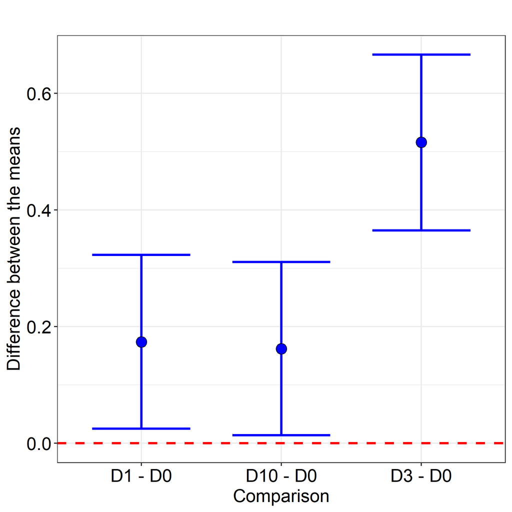

Conclusion: The following pairwise comparisons are statistically significant at the 5% level: (1) D1 - D0, (2) D10 - D0, (3) D3 - D0.

Note: The confidence intervals quoted are not adjusted for multiplicity.

## Analysis description

The data were analysed using a 1-way ANCOVA approach, with Treat1 as the treatment factor and Cov 1 as the covariate.This was followed by comparisons of the predicted means of the Treat1 factor back to the control group mean using Holm's procedure, Holm (1979). This was followed by all pairwise comparisons between the predicted means of the Treat1 factor using Holm's procedure, Holm (1979).

For more information on the theoretical approaches that are implemented within this module, see Bate and Clark (2014).

## References

When referring to InVivoStat, please cite 'InVivoStat, version 5.2.0'.

Bate, S.T. and Clark, R.A. (2014). The Design and Statistical Analysis of Animal Experiments. Cambridge University Press.

Armitage, P., Matthews, J.N.S. and Berry, G. (2001). Statistical Methods in Medical Research. 4th edition; John Wiley & Sons. New York.

Holm, S. (1979). A simple sequentially rejective multiple test procedure. Scandinavian Journal of Statistics, 6, 65-70.

Morris, T.R. (1999). Experimental Design and Analysis in Animal Sciences. CABI publishing. Wallingford, Oxon (UK).

Snedecor, G.W. and Cochran, W.G. (1989). Statistical Methods. 8th edition; Iowa State University Press, Iowa, USA.